# Session1_PDS

## Practical Data Science - Classroom to Careers

### Session-1

The main objective of this session is to explain the pre-requisites before we deal with any kind of Data in general.

#### What is data analysis?

Data Analysis is a subset of Data Science which helps us to understand the underlying process that generates the data

#### What are the different kinds of data?

Data can be mainly categorized into 2 main types -

- Structured Data
- Unstructured data

Examples of **Structured data** include - Tabular data, and mainly easily interpretable by a machine (numeric or can be converted to numeric)

Examples of **Unstructured data** include - Audio, Image or text data etc. which cannot be directly understood by a machine. The way we can transform this data to be understood by machines will be covered in the later part of the course

### Tools we will be using for the course

**Python version 3.6 or higher with Anaconda4** distribution (includes Jupyter/IPython Notebook)

To install Anaconda please visit the following link and choose the version compatible with your Windows OS. Right-click on My Computer/PC and select properties to get the version of your Windows Operating System -

https://repo.anaconda.com/archive/Anaconda3-2020.02-Windows-x86_64.exe (64 bit version)

https://repo.anaconda.com/archive/Anaconda3-2020.02-Windows-x86.exe (32 bit version)

### Course Contents

**1. Basic Probability and Statistics**

- 1.1 Understanding and Representing Data
- 1.2 What are probability distributions?
- 1.3 Bayes Theorem

**2. Probability and Data Distributions**

- 2.1 What are Random Variables?
- 2.2 What is a Probability Density Function?
- 2.3 Normal Distribution
- 2.4 Binomial Distribution
- 2.5 Poisson Distribution
- 2.6 Exponential Distribution
- 2.7 Geometric Distribution

**3. Introduction to Linear Algebra and Calculus**

- 3.1 Matrix Addition and Multiplication
- 3.2 Finding the determinant of a matrix
- 3.3 Eigenvalues and Eigenvectors
- 3.4 Functions
- 3.5 Differentiation of commonly used functions

**4. Statistical Estimation Methods**

- 4.1 Maximum Likelihood Estimates
- 4.2 Information Gain
- 4.3 Parametric Estimation
- 4.4 Non-parametric estimation
- 4.5 Supervised vs. Unsupervised Learning

**5. Regression**

- 5.1 Linear Regression
- 5.2 Logistic regression
- 5.3 Determining the goodness of fit
- 5.4 Decision Trees
- 5.5 Ridge Regression
- 5.6 Lasso Regression
- 5.7 Regularization

**6. Unsupervised Learning**

- 6.1 Hierarchical Clustering
- 6.2 K-Means Clustering
- 6.3 Association Rule mining
- 6.4 Principal Component Analysis (PCA)
- 6.5 Singular Value Decomposition (SVD)
- 6.6 One-class SVM (Anomaly detection)

**7. Supervised Learning in ML**

- 7.1 Bagging/Random Forests
- 7.2 Support Vector Machines (SVM)
- 7.3 Boosting/ Gradient Boosting
- 7.4 Multi-output classification

**8. Introduction to Neural Networks and Cost function**

- 8.1 Artificial Neural Networks
- 8.2 Activation Fucntions
- 8.3 Backpropagation
- 8.4 Gradient Descent
- 8.5 Cost function vs. Loss function

**9. Text Classification**

- 9.1 Bag-of-Words
- 9.2 Named Entity Recognition (NER)
- 9.3 Stemming and Lemmatization
- 9.2 Feature Extraction from Text
- 9.3 Pre-trained Word Embeddings
- 9.4 Text Clustering
- 9.5 Topic Modeling

**10. Sequence Models**

- 10.1 Introduction to Recurrent Neural Networks (RNNs)
- 10.2 Long Short Term Memory Networks (LSTMs)
- 10.3 Gated Recurrent Units
- 10.4 Attention Layers
- 10.5 Multi-Output Classification

**11 and 12 - To be decided**

### Normal Distribution

Also known as Gaussian Distribution, is the most popular Distribution one would hear in Statistics and ML world.

This distribution has a Curve centered at mean and characterized byt the following -

1) Mean

2) Standard Deviation (sigma)

The equation of Normal Distribution is -

\begin{align} P(X=x) = Y = \frac{1}{\sigma\sqrt(2\pi)} * e^{-(x-\mu)^2/2\sigma^2}\\ \end{align}

Where x is a Random Variable and **mu** is the Mean and **sigma** is the Standard deviation

Regression techniques have assumptions built around the data coming from a Normal Distribution

```
[Text(0, 0.5, 'Frequency'), Text(0.5, 0, 'Normal')]
```

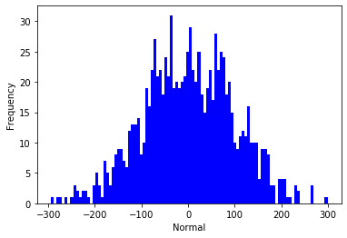

```python
import numpy as np
import scipy
import seaborn as sns


# generate random numbers from N(0,1)
data_normal = np.random.normal(size=1000,loc=0,scale=100)

# Plot the normal distribution
ax = sns.distplot(data_normal,
                  bins=100,
                  kde=False,
                  color='blue',
                  hist_kws={"linewidth": 15,'alpha':1})
ax.set(xlabel='Normal', ylabel='Frequency')
```

#### Properties of normal distribution

- The mean, mode and median are all equal.
- The curve is symmetric at the center (i.e. around the mean, μ).
- Exactly half of the values are to the left of center and exactly half the values are to the right.
- The total area under the curve is 1.

#### Applications of Normal Distribution

**Problem 1**

An average light bulb manufactured by the Acme Corporation lasts 300 days with a standard deviation of 50 days. Assuming that bulb life is normally distributed, what is the probability that an Acme light bulb will last at most 365 days?

**Problem 2**

Suppose scores on an IQ test are normally distributed. If the test has a mean of 100 and a standard deviation of 10, what is the probability that a person who takes the test will score between 90 and 110?

### Binomial Distribution

A binomial distribution is characterized by the following -

- There are **n** repeated trials (where n is a positive integer)
- The trial can result in only 2 outcomes (bi = 2)
- The probability of success for each trial **p** is same and does not change (0<=p<=1)
- The outcome of the trials is independent. i.e., the out come of one trial does not influence the outcome of any other trial

  **Example - Flipping a fair coin**
- The probability of success of head/tail is always 0.5
- The probability of success remains same
- The flipping is independent
- The outcome is either a head or a tail (only 2 outcomes)

**Binomial Distribution Equation**

\begin{equation*} P(E) = {n \choose k} p^k (1-p)^{ n-k} \end{equation*}

**k**: The number of successes that result from the binomial experiment.

**n**: The number of trials in the binomial experiment.

**p**: The probability of success on an individual trial.

**q**: The probability of failure on an individual trial (1-p, since thre are only 2 outcomes)

```
[Text(0, 0.5, 'Frequency'), Text(0.5, 0, 'Binomial')]
```

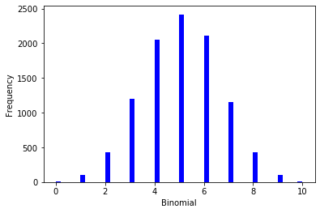

```python
from scipy.stats import binom
import warnings

warnings.filterwarnings(action='ignore')

binom.rvs(size=5,n=10,p=0.5)

data_binom = binom.rvs(n=10,p=0.5,size=10000)

ax = sns.distplot(data_binom,
                  kde=False,
                  color='blue',
                  hist_kws={"linewidth": 15,'alpha':1})

ax.set(xlabel='Binomial', ylabel='Frequency')
```